# Lab 4

### Chelsea Seydlitz

#### Lab Partner: Michael Wang

```python
%matplotlib inline
import h5py
import scipy
import numpy as np
import pandas as pd
import matplotlib as mpl
import matplotlib.pyplot as plt

from scipy import stats,signal

mpl.rcParams['agg.path.chunksize'] = 10000

# Global setup for Problem 1
P1 = h5py.File('gammaray_lab4.h5', 'r')
data = np.array(P1.get('data'))
P1.close()
tgps=data[0]
sp=data[1]
el=data[2]
pc=data[3]

# Global setup for Problem 2
P2=h5py.File('images.h5','r')
img1=np.array(P2.get('image1'))
imgstk=np.array(P2.get('imagestack'))
P2.close()
```

# Problem 1.1

### Next Steps

It is clear that the background will come from the particle count column. As the problem describes, we are searching for gamma rays, but consistently get noise from cosmic rays. We will need to be able to describe the background for this column so that we are able to make conclusions about our observations.

While we will want to show patterns in our other columns and explore the meaning, first I will find a graphical representation of the background distribution for particle count.

First, mu must be found. The math for this is as follows:

```python
lnth=len(pc)
tot=0
for i in pc:
    tot+=i
mu1=tot/lnth
print(f"mu={mu1}")
```

```
mu=7.09730524315952
```

Now with a found mean:

#### $\mu$ = 7.0973

we can create a decent background distribution

The first graph shows that this is poisson distributed. I've added a best fit line over the top. Due to hardware limitations, I was unable to create a line that fit the distribution with the actual data.

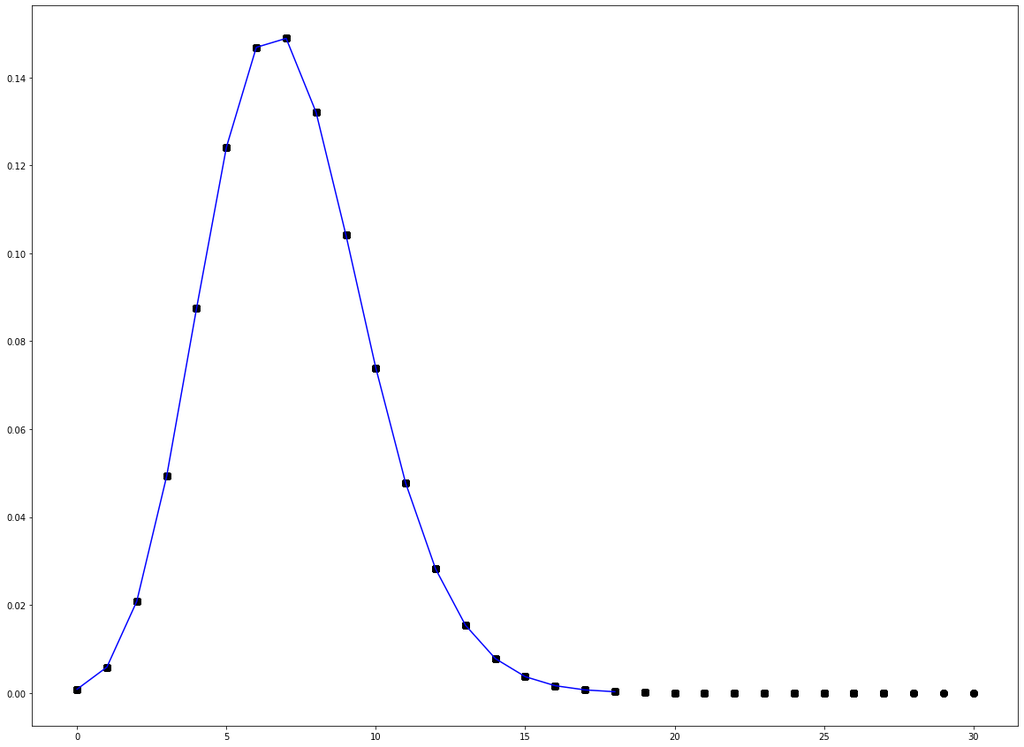

```python
fig, ax = plt.subplots(1, 1, figsize=(20,15))
mpl.rcParams['agg.path.chunksize'] = 10000
x=pc
xlin =np.arange(stats.poisson.ppf(.0001,mu1),stats.poisson.ppf(.9999,mu1))
distlin=stats.poisson.pmf(xlin,mu1)
dist=stats.poisson.pmf(x,mu=mu1)
ax.plot(x, dist,'ko',ms=8)
ax.plot(xlin,distlin,'b')
plt.show()
```

The below graph show the log-scale graph of the above distribution. As is similar with the above, I've added a best-fit line.  
The hope was to see any outliers present in the data with the log-scale distribution. This would have told us where there might be machine failures or general observation failures. However, the data presents itself as a smooth log representation of the above distribution; no obvious bad data is exposed.

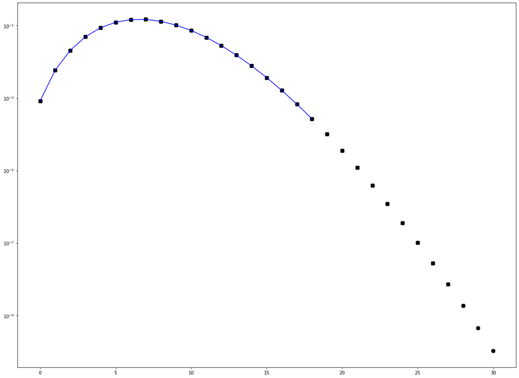

```python
fig, ax = plt.subplots(1, 1, figsize=(20,15))
mpl.rcParams['agg.path.chunksize'] = 10000
x=pc
dist=stats.poisson.pmf(x,mu=mu1)
ax.plot(x, dist,'ko',ms=8)
ax.plot(xlin,distlin,'b')
ax.set_yscale('log')
plt.show()
```

### Exploring the Data

While we do get useful patterns from the data this way, graphing the data in this manner exposed far less than I had hoped. My initial thought was that by graphing the same subset of data over the same iteration, we could see patterns over the visualizations that might indicate a cause in the patterns seen in the particle count.

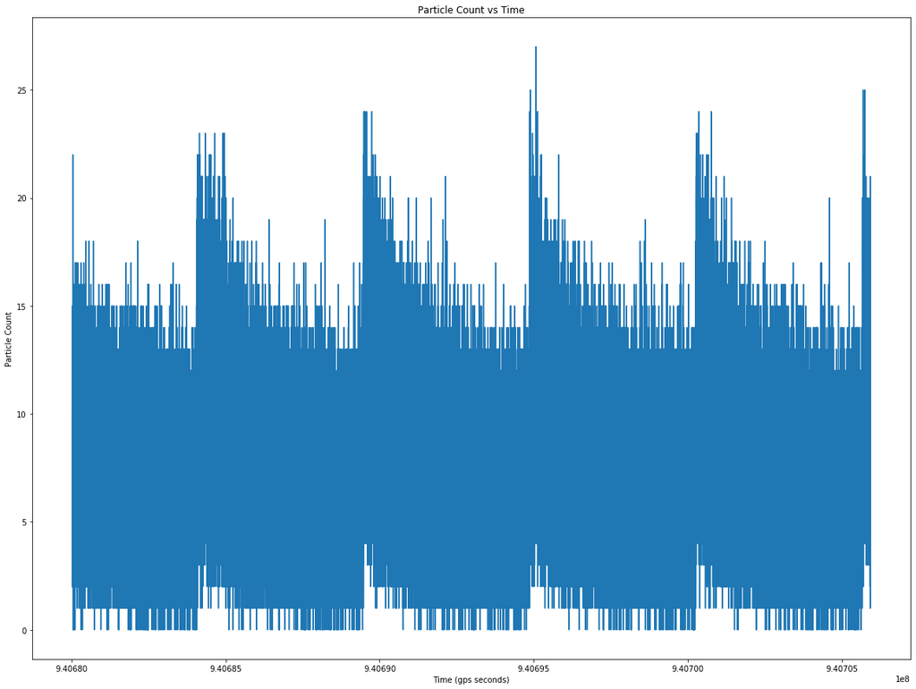

```python
fig, ax = plt.subplots(1, 1, figsize=(20,15))
mpl.rcParams['agg.path.chunksize'] = 10000
subset=int(len(tgps)*.01)
ax.plot(tgps[0:subset],pc[0:subset])
ax.set_title("Particle Count vs Time")
ax.set_ylabel("Particle Count")
ax.set_xlabel("Time (gps seconds)")
plt.show()
```

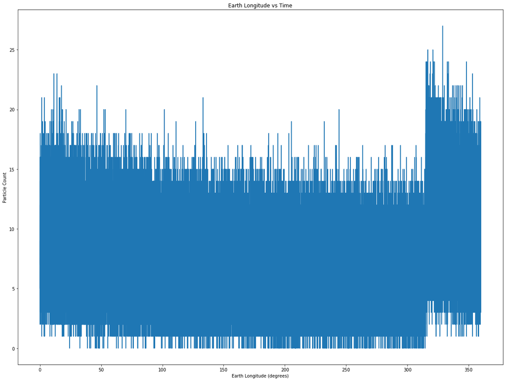

```python
fig, ax = plt.subplots(1, 1, figsize=(20,15))
mpl.rcParams['agg.path.chunksize'] = 10000
subset=int(len(el)*.01)
ax.plot(el[0:subset],pc[0:subset])
ax.set_title("Earth Longitude vs Time")
ax.set_ylabel("Particle Count")
ax.set_xlabel("Earth Longitude (degrees)")
plt.show()
```

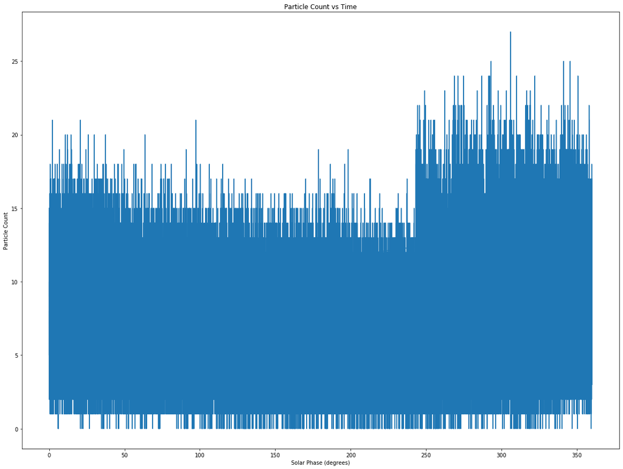

```python
fig, ax = plt.subplots(1, 1, figsize=(20,15))
mpl.rcParams['agg.path.chunksize'] = 10000
subset=int(len(sp)*.01)
ax.plot(sp[0:subset],pc[0:subset])
ax.set_title("Particle Count vs Time")
ax.set_ylabel("Particle Count")
ax.set_xlabel("Solar Phase (degrees)")
plt.show()
```

# Problem 1.2

#### Looking for Inconsistencies

We are looking to compare and describe inconsistencies across the data. Even though the whole data set shows as a nice Poisson distribution, upon closer inspection, across some interval, we may find inconsistencies.

Based on the graph comparing particle count to time, we can see that there is some period of decay that is 90 minutes. This could be a good interval to use when looking for inconsistencies.

#### Path Forward:

There are 54000-100ms intervals in 90 minutes, to show the intervals, we'll put a line at every 54000 interval. Will will omit the very first interval start since we don't know how much data has been cut off.

We can get a good estimate of where our lines should be by saying if the particle equals or exceeds 20, this is where the beginning of our interval begins. To find a good starting point:

```python
t0=0
for i in range(5000,500000):
    if pc[i]>=20:
        print(f"Time index the first time we encounter a particle count of 20 or more: {i}")
        print(f"Time at index {i}: {tgps[i]}")
        t0=i
        break

xposition=[]
for i in range(0,5):
    xposition.append(t0+(54000*i))
```

```
Time index the first time we encounter a particle count of 20 or more: 40572
Time at index 40572: 940684073.2
```

#### Proving the Interval:

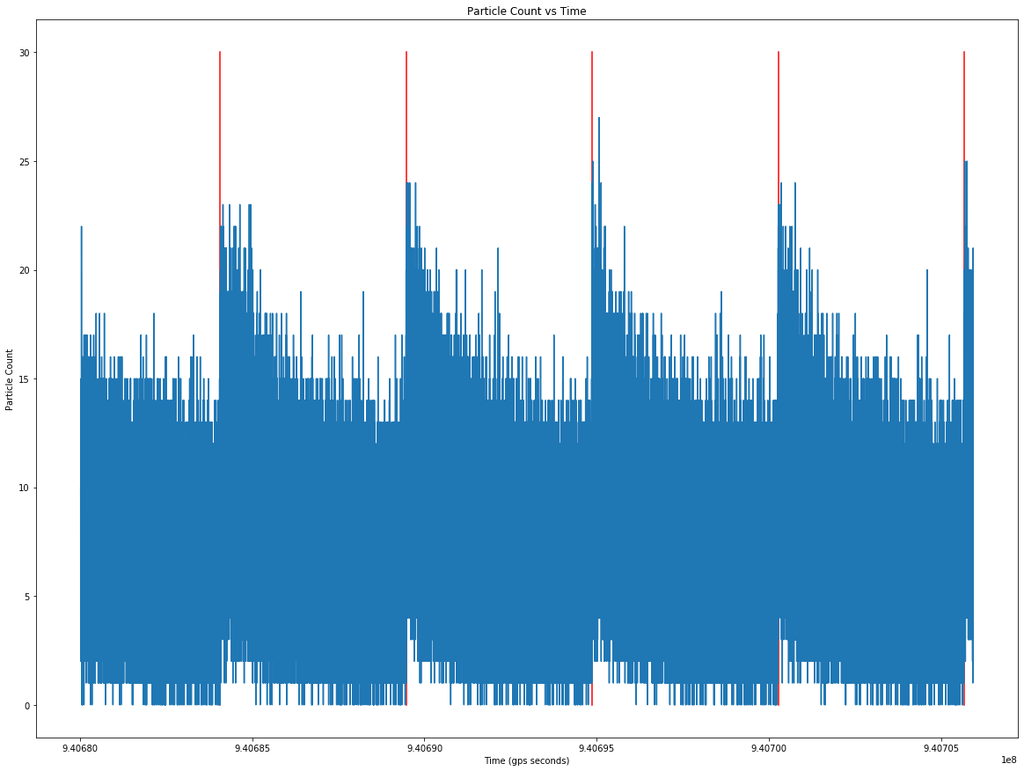

```python
fig, ax = plt.subplots(1, 1, figsize=(20,15))
mpl.rcParams['agg.path.chunksize'] = 10000
subset=int(len(tgps)*.01)

for i in xposition:
    ax.plot((tgps[i],tgps[i]),(0,30),'r-')

ax.plot(tgps[0:subset],pc[0:subset])
ax.set_title("Particle Count vs Time")
ax.set_ylabel("Particle Count")
ax.set_xlabel("Time (gps seconds)")
plt.show()
```

#### Using the Intervals:

Now that we've proven our guess that each visual period is 90 minutes (the time it takes for the instrument to orbit the Earth), we can use the interval to explore inconsistencies.

Below I'll find the average for each section, as well as create the individual sections, in order to create distributions.

```python
averages=[]
time=[]
count=0
sect1=[]
sect2=[]
sect3=[]
sect4=[]
sects=[sect1,sect2,sect3,sect4]

for i in range(1,45):
    time.append(i)
    start=(40572+(54000*count))
    pcss=pc[start:]

    tot=0
    for j in range (0,54000):
        tot+=pcss[j]
    if count<4:
        sects[count].append(pcss[start:start+54000])
    averages.append(tot/54000)
    count+=1
```

# Problem 1.3

Using the data from above, we can take a 90-minute subsection and plot the ideal background (with mean of 7.1) over the top to see how good the fit is. I will use the first full interval, [40572,94572]

```python
xlin=np.arange(stats.poisson.ppf(.0001,7.1),stats.poisson.ppf(.9999,7.1))
distlin=stats.poisson.pmf(xlin,mu=7.1)
```

```python
fig, ax = plt.subplots(1, 1, figsize=(8,8))
x=pcss[40572,94572]
dist=stats.poisson.pmf(x,mu=7.1)
ax.plot(xlin,distlin,'r')
ax.hist(dist,500)
plt.show()
```

[output not shown]